# Introduction to aceDLNM package

In this document, we illustrate the R package `aceDLNM` (https://github.com/tianyi-pan/aceDLNM) for Adaptive Cumulative Exposure Distributed Lag Non-Linear Models (ACE-DLNM).

```r
# install.packages('devtools')
# devtools::install_github('tianyi-pan/aceDLNM')
library(aceDLNM)
library(mgcv)
```

# Overview of ACE-DLNM

Let $Y_t$ be the outcome count at discrete time point $t \in \left\{1, 2, \cdots, N\right\}$. Let $X$ be a continuous exposure process, with collected value $x_t$ at time point $t$. Denote $\boldsymbol{z}_t \in \mathbb{R}^p$ as the vector of covariates. We assume $Y_t | X, \boldsymbol{z}_t$ independently follow a negative binomial distribution $\mathrm{NB}(\mu_t, \theta)$ with mean $\mu_t$, where $\theta$ represents the dispersion parameter. The probability mass function (pmf) is given by
$$p(y_t;\mu_t,\theta) = \frac{\Gamma(y_t + \theta)}{y_t! \Gamma(\theta)}
\left(\frac{\mu_t}{\theta + \mu_t}\right)^y \left(\frac{\theta}{\theta +
\mu_t}\right)^\theta.$$
Then, the variance has the form of $\mathrm{var}\left(Y_t | X, \boldsymbol{z}_t\right) = \mu_t+ \mu_t^2/\theta$.

An ACE-DLNM is specified as
$$\begin{aligned}
Y_t | X, \boldsymbol{z}_t \sim & \mathrm{NB}\left(\mu_t,
\theta\right),\\
\log(\mu_t) =& s(t; X) + \boldsymbol{h}(\boldsymbol{z}_{t}),
\end{aligned}$$
where $\boldsymbol{h}(\boldsymbol{z}_{t}) = \sum_{j=1}^p h_j (\boldsymbol{z}_{tj})$ and $h_j(\boldsymbol{z}_{tj})$ are $p$ unknown smooth functions of covariate $\boldsymbol{z}_{tj}$, $j = 1, \cdots, p$.

We formulate $s(t; X)$, the effect of the exposure process $X$ at time $t$, as follows,
$$s(t;X) = f \left\{\int_{0}^{L} w(l) X(t-l) dl\right\}.$$
Define $E(t) \equiv \int_{0}^{L} w(l) X(t-l) dl$ the **ACE** at (continuous) time $t$, and $f$ the **ACERF**.

# Basic example of ACE-DLNM

## Generate data

We use the function `aceDLNM::GenerateData` to simulate a dataset, to illustrate the main features of `aceDLNM` package.

The exposure $x_t$ is the PM2.5 concentration in Waterloo. Some weight functions and ACERFs are pre-specified in `GenerateData()`. The maximum lag $L$, dispersion parameter $\theta$ and the number of observations are specified by argument `maxL`, `theta`, and `Nt`. A long-term trend function $h(t)$ is considered. That is, the mean model is,
$$\log(\mu_t) = s(t; X) + h(t)$$
We generate the dataset using the following code.

```r
set.seed(12345)

maxL <- 14 # max lag: two week
theta <- 8 # dispersion parameter; var = mu + mu^2/8
Nt <- 1000 # sample size: 1000
wltype <- "type1" # weight function
fEtype <- "cubic" # ACERF

ht <- function(x) sin(x/150) # h(t)
ttmp <- 1:(maxL+Nt)
ttmp <- ttmp[-(1:maxL)]
meanht <- mean(ht(ttmp))
otherterm <- data.frame(trend = ht(ttmp) - meanht)


dat.gen <- GenerateData(fEtype = fEtype, wltype = wltype,
                        Nt = Nt,
                        theta = theta,
                        maxL = maxL,
                        other = otherterm # for other covariates z
                        )

dat <- data.frame(x = dat.gen$x,
                  t = dat.gen$t,
                  y = dat.gen$y)
```

## Fit ACE-DLNM

To fit the ACE-DLNM, we use the function `aceDLNM()`. The distributed lag term and response is in argument `formula`, using the build-in function `sX()`. The long-term trend function $h(t)$ is fitted by a B-spline function of $t$, specified by `mgcv::s`. `kw` and `kE` are the numbers of spline coefficients for $w$ and $f$.

```r
mod.fit <- aceDLNM(formula = y~sX(t, x),
                   smooth = ~s(t, bs = "bs", k = 20),
                   dat = dat,
                   kw = 20,
                   kE = 20,
                   maxL = 14,
                   verbose = FALSE)
```

If `verbose = TRUE`, the progress and diagnostic information will be print, such as the gradients and function values in inner and middle optimizations. For example,

```r
# parameters: 2.054733 3.484608 8.157696 5.458378
# * Start optimize profile likelihood
# -- AlphaF Gradient Max: 5.02176e-12
# -- AlphaF Gradient Max: 9.19265e-13
# -- AlphaF Gradient Max: 9.19265e-13
# -- AlphaF Gradient Max: 7.91697e-09
# -- AlphaF Gradient Max: 7.91697e-09
# -- AlphaF Gradient Max: 4.49796e-12
# -- AlphaF Gradient Max: 4.49796e-12
# -- AlphaF Gradient Max: 1.26299e-12
# -- AlphaF Gradient Max: 1.26299e-12
# * Finish middle opt. Profile Likelihood Gradient Max: 3.28311e-07
# LAML:  1884.214
#
# parameters: 2.054733 3.484608 8.157696 5.458378
# Gradient:  -0.001849584 -0.001983532 -0.0002105075 0.002368254
#
# parameters: 2.054751 3.485166 8.157844 5.457864
```

`parameters: 2.054733 3.484608 8.157696 5.458378` are the current values of $\theta$ and smoothing parameters in outer optimization. Under the parameters, middle optimization (for $w$) is implemented where AlphaF, the spline coefficients for $f$, are found by inner optimization. `-- AlphaF Gradient Max:` reports the final gradient of inner opt and `* Finish middle opt. Profile Likelihood Gradient Max:` report the final gradient of middle optimization. Then, the LAML `LAML: 1884.214` and gradient `Gradient: -0.001849584 -0.001983532 -0.0002105075 0.002368254` are evaluated, which lead to the next BFGS iteration for outer optimization.

The time of model fitting (in seconds) can be found in `mod.fit$opttime`,

```r
mod.fit$opttime
```

```
#> [1] 16.10967
```

## Summarize model

Let’s now summarize the fitted ace-DLNM. The object from `aceDLNM()` is a S3 class.

```r
class(mod.fit)
```

```
#> [1] "aceDLNM_fit"
```

We introduce the S3 functions `summary` and `residuals`.

### `summary()`

The function `summary` is to report the estimated function. The estimates are reported in a dataframe and can also be visualized. We provide the true function in data generating.

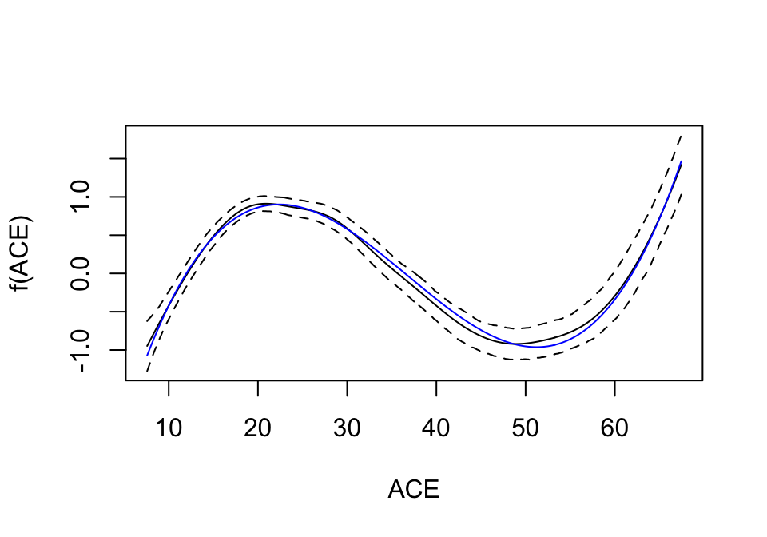

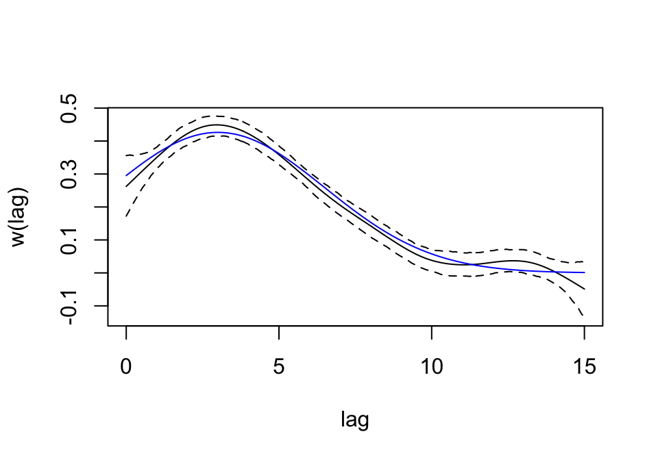

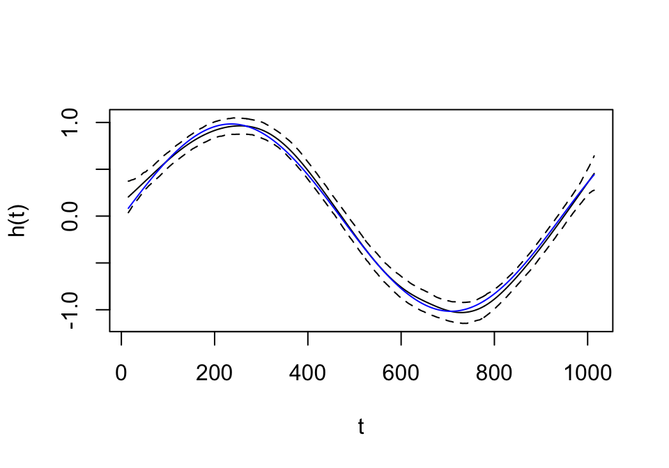

```r
true.function <- dat.gen$true.f
true.function$smooth <- function(x,var){
  if(var == "t") ht(x) - meanht
}

summ <- summary(mod.fit, plot = TRUE, true.function = true.function)
```

The figures for ACERF $f$, weight function $w$ and long-term trend $h$ are reported. The blue curves are the true functions. The point estimates and CIs are demonstrated by solid lines and dashed lines.

The AIC of the fitted model is calculated and save in `summ$AIC` for model comparison,

```r
## l: log likelihood.
## edf0: effective degree of freedom, for conditional AIC,
#        equivalent to the edf in:
#        Hastie, T., and Tibshirani, R. (1990),
#         Generalized Additive Models, London: Chapman & Hall.
## edf: effective degree of freedom, for heuristic alternative,
#       considering the uncertainty in smoothing parameters.
## (coditional) AIC =  -2*summ$AIC$l + 2*summ$AIC$edf0
## AIC = -2*summ$AIC$l + 2*summ$AIC$edf
##
## see details:
#       Wood S N, Pya N, Säfken B. Smoothing parameter and model selection
#       for general smooth models[J]. JASA, 2016, 111(516): 1548-1563.
summ$AIC
```

```
#> $AIC
#> [1] 5615.447
#>
#> $l
#> [1] -2778.793
#>
#> $edf
#> [1] 28.92995
#>
#> $edf0
#> [1] 24.50617
```

### `residuals()`

We provide a function `residuals` for randomized quantile residuals diagnostic.

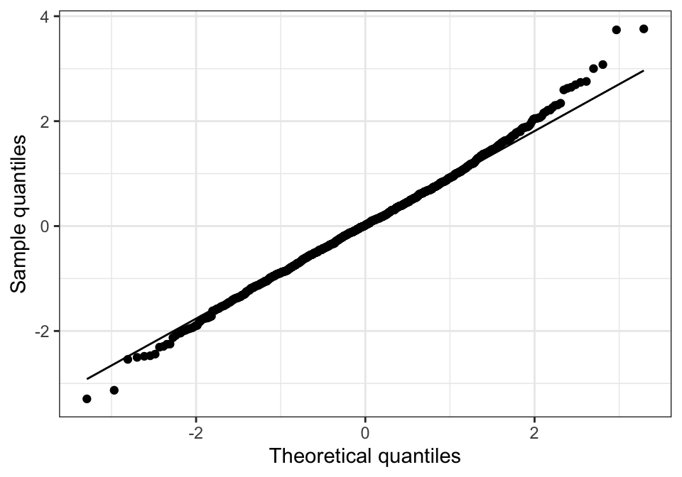

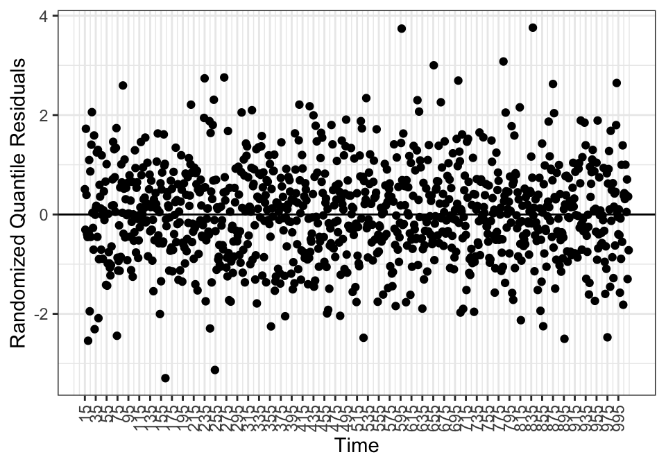

```r
res <- residuals(mod.fit, plot = TRUE)
```